# Análisis experimental del cultivo de piña

Efecto del boro y potasio sobre el ancho del fruto

Autor/a

Lenin Mendoza Llanos

# 1 Análisis de diseño experimental

Se analiza el efecto de siete tratamientos de boro y potasio sobre el ancho del fruto de piña (*Ananas comosus* L. Merr.), variedad Golden MD-2.

# 2 Base de datos

La información proviene de una base experimental organizada en Google Sheets, en la hoja `fb`.

**Variable de respuesta:** ancho del fruto (cm).

# 3 Identificar los factores

- Factor de tratamiento: combinaciones de boro y potasio.
- Factor de bloqueo: bloque experimental.
- Tratamientos: 7.
- Bloques: 4.
- Unidades experimentales: 28.

# 4 Identificar el modelo

Se emplea un Diseño de Bloques Completos al Azar (DBCA), considerando los siete tratamientos.

$$Y_{ij} = \mu + T_i + B_j + \varepsilon_{ij}$$

Donde:

- $Y_{ij}$: ancho promedio del fruto por parcela.
- $\mu$: media general.
- $T_i$: efecto del tratamiento.
- $B_j$: efecto del bloque.
- $\varepsilon_{ij}$: error experimental.

# 5 Project Setup

```r
library(googlesheets4)
library(dplyr)
library(ggplot2)
library(emmeans)
library(multcomp)
library(multcompView)
library(knitr)
```

# 6 Activar los paquetes e importar los datos

```r
googlesheets4::gs4_deauth()

url <- "https://docs.google.com/spreadsheets/d/1oCA7u9mPY7OreIFi4Vi47VAYkhApEFCcQqde4axt8WI/edit?gid=1119977213#gid=1119977213"

fb <- googlesheets4::read_sheet(
  ss = url,
  sheet = "fb"
)

fb <- fb %>%
  mutate(
    tratamiento = as.factor(tratamiento),
    bloque = as.factor(bloque),
    ancho_cm = as.numeric(ancho_cm)
  )

if (median(fb$ancho_cm, na.rm = TRUE) > 1000) {
  fb$ancho_cm <- fb$ancho_cm / 1000
  cat("Se corrigio la escala decimal de ancho_cm.\n")
}
```

```
Se corrigio la escala decimal de ancho_cm.
```

```r
str(fb)
```

```
tibble [28 × 30] (S3: tbl_df/tbl/data.frame)
 $ parcela              : chr [1:28] "P01" "P02" "P03" "P04" ...
 $ tratamiento          : Factor w/ 7 levels "T1","T2","T3",..: 1 1 1 1 2 2 2 2 3 3 ...
 $ bloque               : Factor w/ 4 levels "I","II","III",..: 1 2 3 4 1 2 3 4 1 2 ...
 $ boro_ml              : num [1:28] 0 0 0 0 100 100 100 100 100 100 ...
 $ potasio_ml           : num [1:28] 0 0 0 0 100 100 100 100 150 150 ...
 $ ancho_cm_r1          : num [1:28] 14500 14000 14000 12800 14500 12200 14300 13600 13000 13000 ...
 $ ancho_cm_r2          : num [1:28] 13500 13300 13300 13200 12500 12400 13600 12300 14500 13000 ...
 $ ancho_cm_r3          : num [1:28] 13600 13600 13700 13000 11200 12500 13000 11500 13800 13500 ...
 $ ancho_cm_r4          : num [1:28] 14000 13400 14300 13000 12500 13500 14500 13000 13000 13000 ...
 $ ancho_cm             : num [1:28] 13.9 13.6 13.8 13 12.7 ...
 $ longitud_fruto_cm_r1 : num [1:28] 17400 16700 16500 15700 16100 16200 19800 15000 17500 15500 ...
 $ longitud_fruto_cm_r2 : num [1:28] 16000 16000 16200 16000 15500 14400 18000 15000 18000 16500 ...
 $ longitud_fruto_cm_r3 : num [1:28] 17700 17100 16000 15800 15000 15300 17800 14500 17000 17000 ...
 $ longitud_fruto_cm_r4 : num [1:28] 17500 16600 16500 15000 12200 16700 17200 16500 17500 18700 ...
```

[output cut: 16 more lines]

```r
summary(fb$ancho_cm)
```

```
   Min. 1st Qu.  Median    Mean 3rd Qu.    Max.
  12.60   13.21   13.55   13.51   13.82   14.53
```

```r
stopifnot(
  nrow(fb) == 28,
  !anyNA(fb$ancho_cm),
  median(fb$ancho_cm) > 10,
  median(fb$ancho_cm) < 20
)

knitr::kable(
  fb[, c("parcela", "tratamiento",
         "bloque", "boro_ml",
         "potasio_ml", "ancho_cm")],
  digits = 3,
  caption = "Base de datos organizada"
)
```

Base de datos organizada

| parcela | tratamiento | bloque | boro_ml | potasio_ml | ancho_cm |
| --- | --- | --- | --- | --- | --- |
| P01 | T1 | I | 0 | 0 | 13.900 |
| P02 | T1 | II | 0 | 0 | 13.575 |
| P03 | T1 | III | 0 | 0 | 13.825 |
| P04 | T1 | IV | 0 | 0 | 13.000 |
| P05 | T2 | I | 100 | 100 | 12.675 |
| P06 | T2 | II | 100 | 100 | 12.650 |
| P07 | T2 | III | 100 | 100 | 13.850 |
| P08 | T2 | IV | 100 | 100 | 12.600 |
| P09 | T3 | I | 100 | 150 | 13.575 |
| P10 | T3 | II | 100 | 150 | 13.125 |
| P11 | T3 | III | 100 | 150 | 13.250 |
| P12 | T3 | IV | 100 | 150 | 13.250 |
| P13 | T4 | I | 100 | 200 | 14.375 |
| P14 | T4 | II | 100 | 200 | 13.500 |
| P15 | T4 | III | 100 | 200 | 13.475 |
| P16 | T4 | IV | 100 | 200 | 13.250 |
| P17 | T5 | I | 150 | 100 | 14.375 |
| P18 | T5 | II | 150 | 100 | 13.875 |
| P19 | T5 | III | 150 | 100 | 14.525 |
| P20 | T5 | IV | 150 | 100 | 13.075 |
| P21 | T6 | I | 150 | 150 | 13.625 |
| P22 | T6 | II | 150 | 150 | 13.175 |
| P23 | T6 | III | 150 | 150 | 13.225 |
| P24 | T6 | IV | 150 | 150 | 13.525 |
| P25 | T7 | I | 150 | 200 | 13.675 |
| P26 | T7 | II | 150 | 200 | 13.750 |
| P27 | T7 | III | 150 | 200 | 13.825 |
| P28 | T7 | IV | 150 | 200 | 13.700 |

# 7 Tratamientos experimentales

```r
tratamientos <- fb %>%
  distinct(tratamiento, boro_ml, potasio_ml) %>%
  arrange(tratamiento)

knitr::kable(
  tratamientos,
  caption = "Combinaciones de boro y potasio"
)
```

Combinaciones de boro y potasio

| tratamiento | boro_ml | potasio_ml |
| --- | --- | --- |
| T1 | 0 | 0 |
| T2 | 100 | 100 |
| T3 | 100 | 150 |
| T4 | 100 | 200 |
| T5 | 150 | 100 |
| T6 | 150 | 150 |
| T7 | 150 | 200 |

# 8 Análisis de varianza

El ANOVA permite determinar si existen diferencias estadísticamente significativas entre los siete tratamientos respecto al ancho del fruto de piña.

Se utiliza un nivel de significancia de 5 %.

```r
md <- aov(
  ancho_cm ~ bloque + tratamiento,
  data = fb
)

anova(md)
```

```
Analysis of Variance Table

Response: ancho_cm
            Df Sum Sq Mean Sq F value  Pr(>F)
bloque       3 1.4551 0.48502  3.5876 0.03422 *
tratamiento  6 2.6402 0.44004  3.2548 0.02400 *
Residuals   18 2.4335 0.13520
---
Signif. codes:  0 '***' 0.001 '**' 0.01 '*' 0.05 '.' 0.1 ' ' 1
```

# 9 Interpretación del ANOVA

```r
pvalor <- anova(md)["tratamiento", "Pr(>F)"]

cat("Valor p de tratamientos:",
    signif(pvalor, 4), "\n")
```

```
Valor p de tratamientos: 0.024
```

```r
if (pvalor < 0.05) {
  cat("Existen diferencias estadisticamente
significativas entre los tratamientos
al nivel del 5 %.")
} else {
  cat("No se encontraron diferencias
estadisticamente significativas
entre los tratamientos al nivel del 5 %.")
}
```

```
Existen diferencias estadisticamente
significativas entre los tratamientos
al nivel del 5 %.
```

# 10 Comparación de medias

Se utiliza la prueba de Tukey para comparar las medias de los siete tratamientos, con un nivel de significancia de 5 %.

```r
mc <- emmeans(
  md,
  ~ tratamiento
)

tab <- multcomp::cld(
  mc,
  adjust = "tukey",
  Letters = letters,
  decreasing = TRUE
)

tab$.group <- trimws(tab$.group)

knitr::kable(
  as.data.frame(tab),
  digits = 3,
  caption = "Comparacion de medias de Tukey al 5 %"
)
```

Comparacion de medias de Tukey al 5 %

|  | tratamiento | emmean | SE | df | lower.CL | upper.CL | .group |
| --- | --- | --- | --- | --- | --- | --- | --- |
| 2 | T5 | 13.963 | 0.184 | 18 | 13.407 | 14.518 | a |
| 3 | T7 | 13.738 | 0.184 | 18 | 13.182 | 14.293 | ab |
| 6 | T4 | 13.650 | 0.184 | 18 | 13.094 | 14.206 | ab |
| 1 | T1 | 13.575 | 0.184 | 18 | 13.019 | 14.131 | ab |
| 4 | T6 | 13.388 | 0.184 | 18 | 12.832 | 13.943 | ab |
| 7 | T3 | 13.300 | 0.184 | 18 | 12.744 | 13.856 | ab |
| 5 | T2 | 12.944 | 0.184 | 18 | 12.388 | 13.500 | b |

Los tratamientos que comparten una o más letras no presentan diferencias estadísticamente significativas entre sí.

# 11 Representación gráfica

Se presentan las medias ajustadas de los tratamientos, con sus errores estándar y letras de significancia de Tukey.

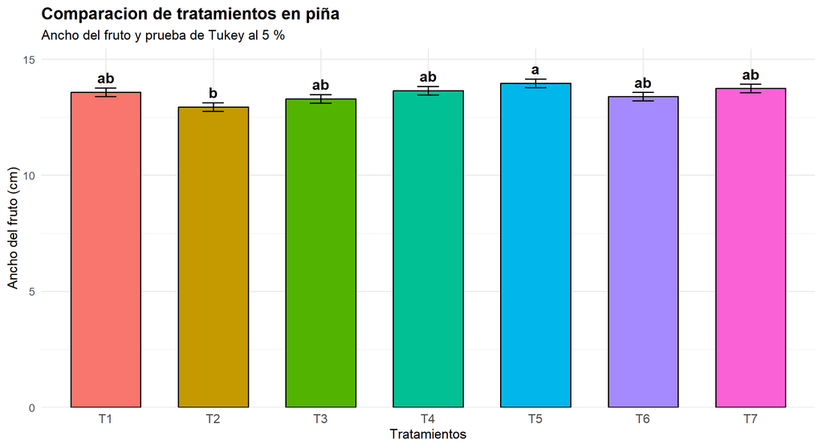

```r
grafico <- as.data.frame(tab)

pl <- ggplot(
  grafico,
  aes(
    x = tratamiento,
    y = emmean,
    fill = tratamiento
  )
) +
  geom_col(
    width = 0.65,
    color = "black",
    show.legend = FALSE
  ) +
  geom_errorbar(
    aes(
      ymin = emmean - SE,
      ymax = emmean + SE
    ),
    width = 0.2
  ) +
geom_text(
  aes(
    y = emmean + SE + 0.45,
    label = .group
  ),
  size = 5,
  fontface = "bold",
  color = "black"
) +
  scale_y_continuous(
    limits = c(
      0,
      max(grafico$emmean + grafico$SE) + 1
    ),
    expand = expansion(mult = c(0, 0.02))
  ) +
  labs(
    title = "Comparacion de tratamientos en piña",
    subtitle = "Ancho del fruto y prueba de Tukey al 5 %",
    x = "Tratamientos",
    y = "Ancho del fruto (cm)"
  ) +
  theme_minimal(base_size = 13) +
  theme(
    plot.title = element_text(
      face = "bold",
      size = 16
    ),
    axis.text.x = element_text(size = 12)
  )

print(pl)
```

# 12 Conclusiones

El análisis estadístico permite evaluar las diferencias entre los tratamientos de boro y potasio respecto al ancho del fruto de piña.

La prueba de Tukey permite identificar cuáles tratamientos presentan diferencias estadísticamente significativas.

La gráfica facilita la comparación de los tratamientos mediante sus medias ajustadas, errores estándar y letras de significancia.

# 13 Referencia

Chacón Huamaní, D. (2019). Boro y potasio en post inducción de *Ananas comosus* L. Merr. de la variedad Golden MD-2 en Río Negro. Universidad Nacional del Centro del Perú.